# STAA 566 HW3

Ryan Miller

The data for this project comes from the US Census Boundary and Attribute Data via [tidycensus](https://cran.r-project.org/web/packages/tidycensus/index.html).

The maps display household size proportions by state in the U.S.A.

I think that this data gives insight to the life-styles in different parts of the country, and therefore I find it interesting.

I chose to display the maps using `coord_map( 'conic', lat0 = 30 )` in order for the map to not be skewed; i.e., the sizes of the states to not be distorted.

I plotted the data in two ways, first using a consistent color scaling so that the scale would be the same across the maps, which I thought would be helpful in interpreting the results and identifying overall trends. This can be seen in the first 3x2 set of plots. I used the `magma` color map on these plots because I thought it was the most interpretable given the scale.

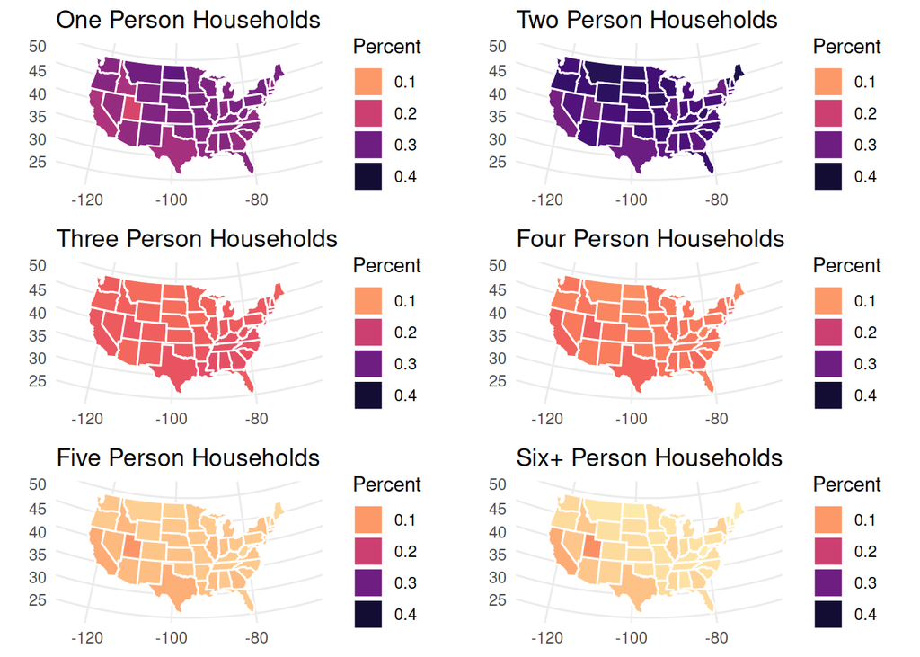

For the second way of plotting, I made individual maps, each with it’s own color scaling. Since the color scales are not consistent, it allows differences to be seen in finer detail. But since the scales are no longer consistent, I did not think plotting them all together would make sense, so they are each their own plot. This set of plots also includes an extra 7+ Person Households. Here I used a different color map, `viridis`, for two reasons. First to highlight the different scaling from the plots above. Second, because the color scale is tailored to each individual plot, this map provided better interpretability.

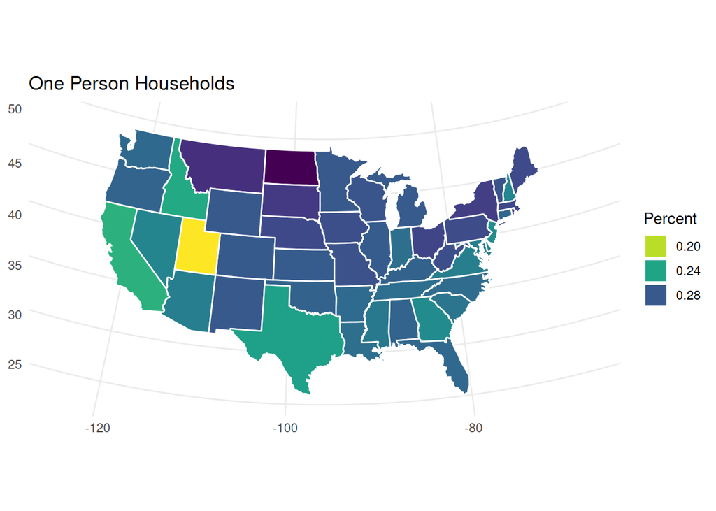

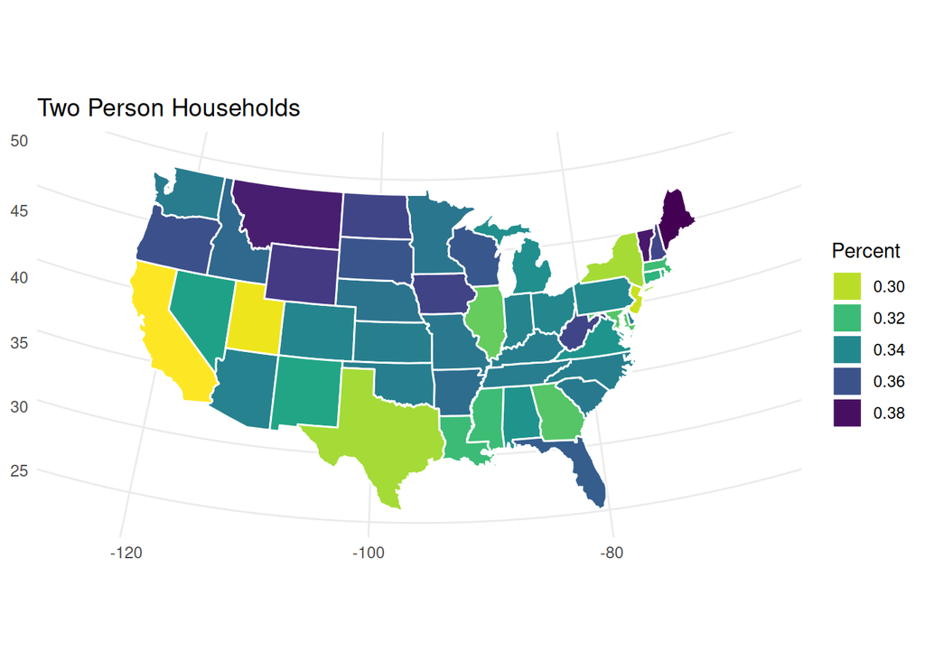

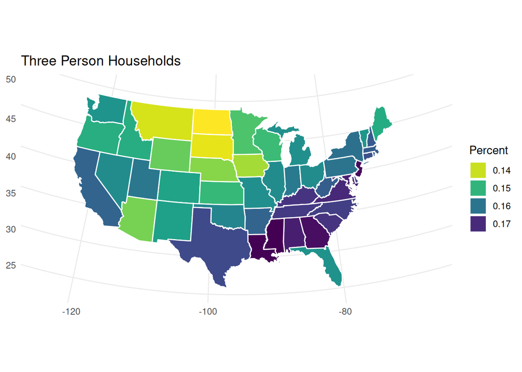

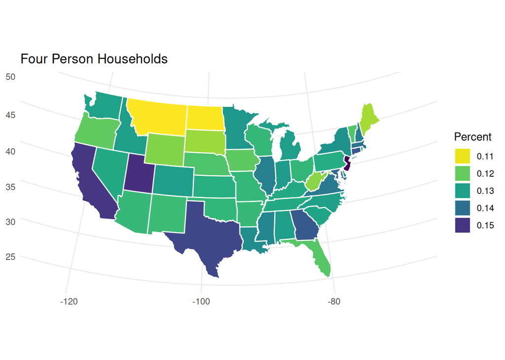

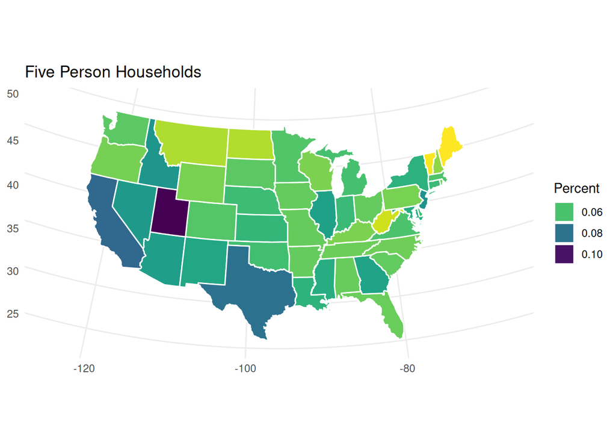

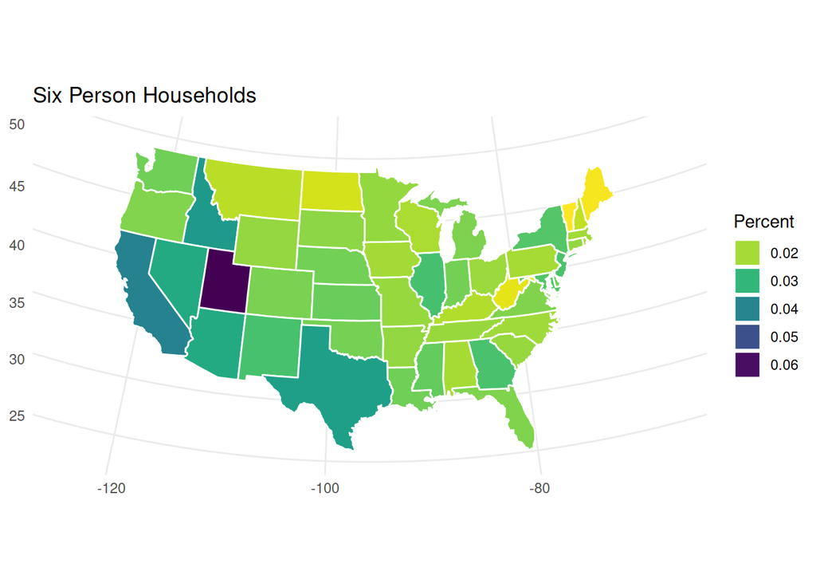

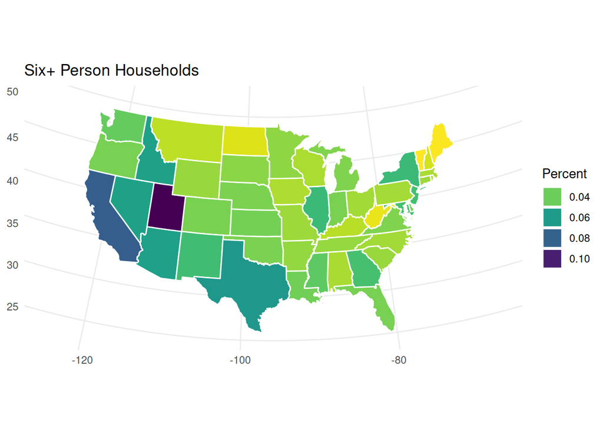

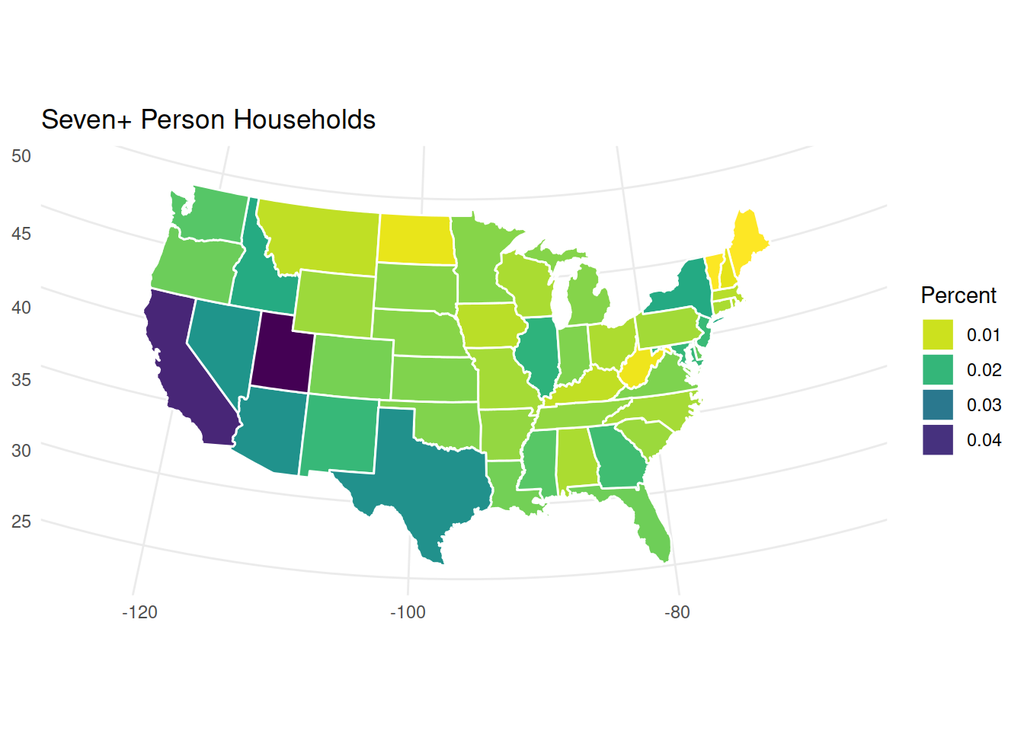

## Code

```r
## Load required libraries
library( gridExtra  )
library(  mapproj   )   # Req'd for mapping
library(   maps     )   # Req'd for mapping
library(    sf      )   # Req'd for simple features mapping
library( tidycensus )   # Req'd for data retrieval
library( tidyverse  )
library(   units    )   # Req'd for mapping
library(  viridis   )

## Clear function for ease (by default keeps all functions)
# Optional input E - character array of exceptions
# Optional input P - character array of inclusions
clear <- function( all = FALSE, E = "", P = "" )
{
    # By default don't clear the loaded data unless intentionally cleared
    if( ! all ){ E <- c( E, 'api.key' ) }

    # Get list of functions and exclude anything in E
    l <- setdiff( ls(envir=parent.frame()), c( lsf.str(envir=parent.frame()), E ) )

    # Add P to the list.
    if( all( P != "" ) ){ l <- c( l, P ) }

    # Remove the stuff
    rm( list = l, envir = parent.frame() )
}

## Clear things
clear( )

##########################################################################################
## End Setup
##########################################################################################

## Get CENSUS_API_KEY for querying data
if( !exists( 'api.key' ) || api.key == '' )
{
    readRenviron( '~/.Renviron' )
    api.key <- Sys.getenv( 'CENSUS_API_KEY' )
}
if( api.key == '' ){ stop('API KEY ERROR'); }

## Get the household size
hs <- get_decennial( geography = 'state', variables = c( 'H013001', 'H013002', 'H013003',
                                                        'H013004', 'H013005', 'H013006',
                                                        'H013007', 'H013008' ) )

## Get U.S.A state data
states <- map_data( 'state' ) %>% mutate( region = str_to_title( region ) )
head( hs )
head( states )

## There's almost certainly an easier way to do this in tidyverse
tot   <- which( hs$variable == 'H013001' )
op    <- which( hs$variable == 'H013002' )
twp   <- which( hs$variable == 'H013003' )
thp   <- which( hs$variable == 'H013004' )
frp   <- which( hs$variable == 'H013005' )
fvp   <- which( hs$variable == 'H013006' )
sxp   <- which( hs$variable == 'H013007' )
spp   <- which( hs$variable == 'H013008' )
p.op  <- hs$value[ op ] / hs$value[ tot ]
p.twp <- hs$value[ twp ] / hs$value[ tot ]
p.thp <- hs$value[ thp ] / hs$value[ tot ]
p.fpp <- sum( c(hs$value[ frp ], hs$value[ fvp ], hs$value[ sxp ], hs$value[ spp ] ) ) / hs$value[ tot ]

## Update the housing data
h.data <- hs[ tot, ]
h.data <- h.data %>% select( -c(variable, value ) ) %>%
    mutate( Total = hs$value[ tot ],
    One.Person = hs$value[ op ] / Total,
    Two.Person    = hs$value[ twp ] / Total,
    Three.Person  = hs$value[ thp ] / Total,
    Four.Person   = hs$value[ frp ] / Total,
    Five.Person   = hs$value[ fvp ] / Total,
    Six.Person    = hs$value[ sxp ] / Total,
    SevenP.Person = hs$value[ spp ] / Total )

# Ensure percentages sum to 1
rowSums( data.matrix( h.data[ , 4:10 ]) )

## Plot data for the four plots
pd <- vector( 'list', 8 )
pd[[1]] <- h.data %>% mutate( p = One.Person    ) %>% select( NAME, p )
pd[[2]] <- h.data %>% mutate( p = Two.Person    ) %>% select( NAME, p )
pd[[3]] <- h.data %>% mutate( p = Three.Person  ) %>% select( NAME, p )
pd[[4]] <- h.data %>% mutate( p = Four.Person   ) %>% select( NAME, p )
pd[[5]] <- h.data %>% mutate( p = Five.Person   ) %>% select( NAME, p )
pd[[6]] <- h.data %>% mutate( p = Six.Person    ) %>% select( NAME, p )
pd[[7]] <- h.data %>% mutate( p = SevenP.Person ) %>% select( NAME, p )
pd[[8]] <- h.data %>% mutate( p = Six.Person + SevenP.Person ) %>% select( NAME, p )

pd[[1]]$title <- 'One Person Households'
pd[[2]]$title <- 'Two Person Households'
pd[[3]]$title <- 'Three Person Households'
pd[[4]]$title <- 'Four Person Households'
pd[[5]]$title <- 'Five Person Households'
pd[[6]]$title <- 'Six Person Households'
pd[[7]]$title <- 'Seven+ Person Households'
pd[[8]]$title <- 'Six+ Person Households'

## Get the range of percentages
rngs <- unlist( lapply( pd, function(p){ range( p$p ) } ) )
rngs
min.p <- min( rngs )
# [1] 0.007083391
max.p <- max( rngs )
# [1] 0.4402997

## Create a map of the U.S.A colored by household size w/consistent palette
h <- lapply( pd, function( p )
            {
                pd_ <- states %>% left_join( p, c( 'region' = 'NAME' ) )
                ttl <- p$title[1]

                h_ <- ggplot( data = pd_, aes( x = long, y = lat, group = group,
                                              fill = p ) ) +
                    geom_polygon( color = 'white' ) +
                    scale_fill_viridis( limits = c(min.p, max.p), direction = -1,
                                       option = 'A' ) +
                    theme_minimal() + theme( axis.title = element_blank() ) +
                    ggtitle( ttl ) +
                    guides( fill = guide_legend( title = 'Percent' ) ) +
                    coord_map( 'conic', lat0 = 30 )

                return( h_ )
            } )
grid.arrange( h[[1]], h[[2]], h[[3]], h[[4]], h[[5]], h[[8]],  nrow = 3, ncol = 2 )
hi <- lapply( pd, function( p )
            {
                pd_ <- states %>% left_join( p, c( 'region' = 'NAME' ) )
                ttl <- p$title[1]

                h_ <- ggplot( data = pd_, aes( x = long, y = lat, group = group,
                                              fill = p ) ) +
                    geom_polygon( color = 'white' ) +
                    scale_fill_viridis( direction = -1 ) +
                    theme_minimal() + theme( axis.title = element_blank() ) +
                    ggtitle( ttl ) +
                    guides( fill = guide_legend( title = 'Percent' ) ) +
                    coord_map( 'conic', lat0 = 30 )

                return( h_ )
            } )
for( i in 1:( length( hi )-2) )
{
    print( hi[[i]] )
}
hi[[length(hi)]]
hi[[length(hi)-1]]
```